# Mpem&Djim and Nachtigal data

Gilles Dauby

2025-10-23

```r
# to install the package 'plotsdatabase'
# make sure you are running recent R version

devtools::install_github("gdauby/bdd_plots_central_africa")
## if the installation above failed, it may be because your timeout is too low
## you can increase the timeout by using the following code
options(timeout = 1000)


library(tidyverse)
library(plotsdatabase) ## R package for exploring the database
library(sf)
library(BIOMASS)
library(ade4)
library(mapview)
library(gt)
library(vegan)

# options(repos = c(
#   rtrees = 'https://daijiang.r-universe.dev',
#   CRAN = 'https://cloud.r-project.org'))
# install.packages("rtrees")
library(rtrees)

mydb <- call.mydb(use_env_credentials = T)
mydb.taxa <- call.mydb.taxa(use_env_credentials = T)
# mydb <- call.mydb(pass = "xxx", user = "xxx")
# mydb.taxa <- call.mydb(pass = "xxx", user = "xxx")
```

Vérifier que la version du package est bien la [dernière en ligne](https://github.com/gdauby/bdd_plots_central_africa/blob/master/DESCRIPTION).

```r
packageVersion("plotsdatabase")
```

```
## [1] '1.4'
```

# Extraire les données

## Extraire les données pour le Mpem et Nachtigal.

```r
meta_data <-
  query_plots(
    locality_name = c("Mpem", "Nachtigal"),
    remove_ids = F,
  )
```

```r
dataset <-
  query_plots(
    locality_name = c("Mpem", "Nachtigal"),
    remove_ids = F,
    extract_individuals = T,
    traits_to_genera = T ## wood density will be given to stems identified at genus level (if any data for species of those genus) and if not data, wd averaged at plot level will be given
  )
```

```r
meta_data %>%
  group_by(method) %>%
  count() %>%
  gt::gt()
```

[output not shown]

## Ajout d’une colonne pour les plots de savanes et de forêt.

```r
dataset <-
  dataset %>%
  left_join(meta_data %>% select(id_liste_plots, method),
            by = c("id_table_liste_plots_n" = "id_liste_plots")) %>%
  mutate(biome = case_when(
    grepl("1ha-IRD", method) ~ "forest",
    grepl("Savana", method) ~ "savana"
  ))


meta_data <-
  meta_data %>%
  mutate(biome = case_when(
    grepl("1ha-IRD", method) ~ "forest",
    grepl("Savana", method) ~ "savana"
  ))
```

## Extraire les données spatiales si présentes

```r
spatial_data <-
  query_plots(
    plot_name = meta_data %>% filter(!is.na(biome)) %>% pull(plot_name), ## sélection des parcelles forêts/savanes
    remove_ids = F,
    show_all_coordinates = T
  )

spatial_data <-
  spatial_data$coordinates_sf


## ajout de la colonne indiquant le biome
spatial_data <-
  spatial_data %>%
  left_join(meta_data %>% select(plot_name, biome))


## exporter les données en gpkg
write_sf(spatial_data, "plots_data_polygons.gpkg")


data_sf <-
  meta_data %>%
  select(plot_name, biome, ddlat, ddlon) %>%
  #### plots de savannes récents sans coordonnées !!!!
  filter(!is.na(ddlat)) %>%
  st_as_sf(coords = c("ddlon", "ddlat"))
st_crs(data_sf) <- 4326
```

# Cartographies

## Carto des inventaires sous forme de points.

```r
mapview::mapview(data_sf, zcol = "biome")
```

[interactive chart not shown]

## Carto des polygones si disponible.

```r
mapview::mapview(spatial_data, zcol = "biome")
```

[interactive chart not shown]

# Process des données pour estimation de AGB

# height-diameter models - BIOME level

# Predict height based h-d models - BIOME level

# Predict height based h-d models - PLOT level

# AGB predictions

```r
AGB_simu %>%
  mutate(across(where(is.numeric), ~round(., 2))) %>%
  gt::gt()
```

[output not shown]

# Diversity patterns

## Traits

### Guilds

Calcul des proportions de chaque *guild*

```r
guild_proportion <-
  dataset %>%
  filter(!is.na(biome)) %>%
  rename(guild = taxa_succession_guild) %>%
  mutate(guild = gsub(" ", "_", guild)) %>%
  mutate(guild = gsub("-", "_", guild)) %>%
  group_by(plot_name, guild) %>%
  count() %>%
  ungroup() %>%
  group_by(plot_name) %>%
  mutate(proportion = round( n/sum(n)*100, 1)) %>%
  ungroup() %>%
  select(-n) %>%
  pivot_wider(names_from = guild,
              values_from = proportion, values_fill = 0) %>%
  left_join(meta_data %>% select(plot_name, biome))
```

### Phénologie

Calcul des proportions de chaque *comportement phénologique* (selon littérature)

```r
phenology_proportion <-
  dataset %>%
  filter(!is.na(biome)) %>%
  rename(phenology = taxa_phenology) %>%
  mutate(phenology = gsub(" ", "_", phenology)) %>%
  mutate(phenology = gsub("-", "_", phenology)) %>%
  group_by(plot_name, phenology) %>%
  count() %>%
  ungroup() %>%
  group_by(plot_name) %>%
  mutate(proportion = round( n/sum(n)*100, 1)) %>%
  ungroup() %>%
  select(-n) %>%
  pivot_wider(names_from = phenology,
              values_from = proportion, values_fill = 0) %>%
  left_join(meta_data %>% select(plot_name, biome))
```

### Densité de bois

Calcul de la *densité moyenne du bois* par plot - attribuée aux taxas si existant, sinon moyenne du genre, sinon moyenne du plot.

```r
wood_density_mean <-
  dataset %>%
  filter(!is.na(biome)) %>%
  group_by(plot_name) %>%
  summarise(wd = round(mean(taxa_mean_wood_density), 2))
```

### Table des attributs ‘fonctionnel’ par plot

|  | plot_name | deciduous | pioneer | ddlat | ddlon | wd |
| --- | --- | --- | --- | --- | --- | --- |
| 1 | kounoungou001 | 57.3 | 32.8 | 5.0441895 | 11.621795 | 0.52 |
| 2 | kounoungou002 | 51.2 | 22.8 | 5.0456033 | 11.627695 | 0.53 |
| 3 | kounoungou003 | 54.7 | 37.9 | 5.04209 | 11.61663 | 0.51 |
| 4 | mpem001 | 21.3 | 8.4 | 5.01806 | 11.6558 | 0.61 |
| 5 | mpem002 | 44.1 | 10.9 | 5.03236 | 11.6479 | 0.66 |
| 6 | mpem003 | 12.6 | 13.3 | 5.02234 | 11.6479 | 0.64 |
| 7 | mpem004 | 27.9 | 15.5 | 5.01434 | 11.652 | 0.63 |
| 8 | mpem005 | 33.6 | 18.3 | 5.17896 | 11.5615 | 0.61 |
| 9 | mpem006 | 26.9 | 60.1 | 5.16829 | 11.5848 | 0.52 |
| 10 | mpem007 | 32.5 | 15.9 | 5.18058 | 11.586 | 0.6 |

[output cut: 83 more lines]

## Tables de contingence pour chaque biome

```r
dataset_sub <-
  dataset %>%
  filter(grepl("Mpem", locality_name))

sp_plot_mat_forest <-
  species_plot_matrix(data_tb = dataset_sub %>%
                        filter(biome == "forest"))
```

```
## ℹ Removing 773 unidentified individuals
```

```r
sp_plot_mat_savana <-
  species_plot_matrix(data_tb = dataset_sub %>%
                        filter(biome == "savana"))
```

```
## ℹ Removing 714 unidentified individuals
```

## NSCA

### Forêts

```r
nsc_forests <-
  dudi.nsc(df = t(sp_plot_mat_forest), nf = 3, scannf = FALSE)

scores <- as_tibble(nsc_forests$l1)
scores <-
  scores %>%
  mutate(plot_name = row.names(nsc_forests$l1))

variables <- as_tibble(nsc_forests$co)
variables <-
  variables %>%
  mutate(taxa = row.names(nsc_forests$co)) %>%
  filter()
```

#### Axes 1 et 2

```r
## Fit des 'attributs' sur les plans d'ordination

fit <- envfit(
  nsc_forests$li,
  plot_data %>%
    filter(plot_name %in% scores$plot_name) %>%
    column_to_rownames(var = "plot_name"),
  permutations = 999
)

tibble(pvalue = fit$vectors$pvals,
       variable = names(fit$vectors$pvals)) %>%
  gt::gt()
```

| pvalue | variable |
| --- | --- |
| 0.001 | deciduous |
| 0.599 | pioneer |
| 0.517 | ddlat |
| 0.936 | ddlon |
| 0.095 | wd |

```r
## Axis 1 and 2

arrow_df <- as.data.frame(scores(fit, display = "vectors"))
arrow_df$variable <- rownames(arrow_df)
arrow_df$Axis1 <- arrow_df$Axis1 * 2
arrow_df$Axis2 <- arrow_df$Axis1 * 2


variables_filtered <- variables %>%
  mutate(length = sqrt(Comp1^2 + Comp2^2)) %>%
  filter(length > 3)

eig_percent <- 100 * nsc_forests$eig / sum(nsc_forests$eig)

gg12 <-
  ggplot() +
  geom_point(
    data = scores,
    mapping = aes(x = RS1, y = RS2),
    size = 3,
    color = "steelblue"
  ) +
  geom_text(
    data = scores,
    mapping = aes(x = RS1, y = RS2, label = plot_name),
    vjust = -0.5,
    size = 3
  ) +
  labs(
    x = paste0("(", round(eig_percent[1], 1), "%)"),
    y = paste0("(", round(eig_percent[2], 1), "%)"),
    title = "NSCA"
  ) +
  geom_segment(data = variables_filtered,
               aes(x = 0, y = 0, xend = Comp1, yend = Comp2),
               arrow = arrow(length = unit(0.25, "cm")), color = "red") +
  geom_text(data = variables_filtered,
            aes(x = Comp1, y = Comp2, label = taxa),
            color = "red", vjust = -0.5) +
  theme_minimal() +
  geom_segment(data = arrow_df, aes(x = 0, y = 0, xend = Axis1, yend = Axis2),
               arrow = arrow(length = unit(0.25, "cm")), color = "darkgreen") +
  geom_text(data = arrow_df, aes(x = Axis1, y = Axis2, label = variable),
            color = "darkgreen", vjust = -0.5)

plotly::ggplotly(gg12)
```

[interactive chart not shown]

#### Axes 2 et 3

```r
## Fit des 'attributs' sur les plans d'ordination

fit <- envfit(
  nsc_forests$li[,c(2, 3)],
  plot_data %>%
    filter(plot_name %in% scores$plot_name) %>%
    column_to_rownames(var = "plot_name"),
  permutations = 999
)

tibble(pvalue = fit$vectors$pvals,
       variable = names(fit$vectors$pvals)) %>%
  gt::gt()
```

| pvalue | variable |
| --- | --- |
| 0.225 | deciduous |
| 0.336 | pioneer |
| 0.294 | ddlat |
| 0.866 | ddlon |
| 0.015 | wd |

```r
## Axis 2 and 3


arrow_df <- as.data.frame(scores(fit, display = "vectors"))
arrow_df$variable <- rownames(arrow_df)
arrow_df$Axis2 <- arrow_df$Axis2 * 2
arrow_df$Axis3 <- arrow_df$Axis3 * 2


variables_filtered <- variables %>%
  mutate(length = sqrt(Comp2^2 + Comp3^2)) %>%
  filter(length > 3)

eig_percent <- 100 * nsc_forests$eig / sum(nsc_forests$eig)

gg23 <- ggplot() +
  geom_point(
    data = scores,
    mapping = aes(x = RS2, y = RS3),
    size = 3,
    color = "steelblue"
  ) +
  geom_text(
    data = scores,
    mapping = aes(x = RS2, y = RS3, label = plot_name),
    vjust = -0.5,
    size = 3
  ) +
  labs(
    x = paste0(" (", round(eig_percent[2], 1), "%)"),
    y = paste0(" (", round(eig_percent[3], 1), "%)"),
    title = "NSCA"
  ) +
  geom_segment(data = variables_filtered,
               aes(x = 0, y = 0, xend = Comp2, yend = Comp3),
               arrow = arrow(length = unit(0.25, "cm")),
               color = "red") +
  geom_text(data = variables_filtered,
            aes(x = Comp2, y = Comp3, label = taxa),
            color = "red", vjust = -0.5) +
  theme_minimal() +
  geom_segment(data = arrow_df,
               aes(x = 0, y = 0, xend = Axis2, yend = Axis3),
               arrow = arrow(length = unit(0.25, "cm")),
               color = "darkgreen") +
  geom_text(data = arrow_df,
            aes(x = Axis2, y = Axis3, label = variable),
            color = "darkgreen", vjust = -0.5)

plotly::ggplotly(gg23)
```

[interactive chart not shown]

```r
georef_scores <-
  data_sf %>%
  left_join(scores) %>%
  filter(!is.na(RS1))
```

```r
mapview(georef_scores, zcol = "RS1") +
  mapview(georef_scores, zcol = "RS2") +
  mapview(georef_scores, zcol = "RS3")
```

[interactive chart not shown]

### Savanes

```r
nsc_savana <-
  dudi.nsc(df = t(sp_plot_mat_savana), nf = 3, scannf = FALSE)

scores <- as_tibble(nsc_savana$l1)
scores <-
  scores %>%
  mutate(plot_name = row.names(nsc_savana$l1))

variables <- as_tibble(nsc_savana$co)
variables <-
  variables %>%
  mutate(taxa = row.names(nsc_savana$co)) %>%
  filter()
```

#### Axes 1 et 2

```r
## Axis 1 and 2

variables_filtered <- variables %>%
  mutate(length = sqrt(Comp1^2 + Comp2^2)) %>%
  filter(length > 3)

# Optional: calculate % variance explained for axis labels
eig_percent <- round(100 * nsc_savana$eig / sum(nsc_savana$eig), 1)

gg12 <-
  ggplot() +
  geom_point(
    data = scores,
    mapping = aes(x = RS1, y = RS2),
    size = 3,
    color = "steelblue"
  ) +
  geom_text(
    data = scores,
    mapping = aes(x = RS1, y = RS2, label = plot_name),
    vjust = -0.5,
    size = 3
  ) +
  labs(
    x = paste0("(", round(eig_percent[1], 1), "%)"),
    y = paste0("(", round(eig_percent[2], 1), "%)"),
    title = "NSCA"
  ) +
  geom_segment(data = variables_filtered,
               aes(x = 0, y = 0, xend = Comp1, yend = Comp2),
               arrow = arrow(length = unit(0.25, "cm")),
               color = "red") +
  geom_text(data = variables_filtered,
            aes(x = Comp1, y = Comp2, label = taxa),
            color = "red", vjust = -0.5) +
  theme_minimal()

plotly::ggplotly(gg12)
```

[interactive chart not shown]

#### Axes 2 et 3

```r
## Axis 2 and 3

variables_filtered <- variables %>%
  mutate(length = sqrt(Comp2^2 + Comp3^2)) %>%
  filter(length > 3)

# Optional: calculate % variance explained for axis labels
eig_percent <- 100 * nsc_savana$eig / sum(nsc_savana$eig)

gg23 <- ggplot() +
  geom_point(
    data = scores,
    mapping = aes(x = RS2, y = RS3),
    size = 3,
    color = "steelblue"
  ) +
  geom_text(
    data = scores,
    mapping = aes(x = RS2, y = RS3, label = plot_name),
    vjust = -0.5,
    size = 3
  ) +
  labs(
    x = paste0(" (", round(eig_percent[2], 1), "%)"),
    y = paste0(" (", round(eig_percent[3], 1), "%)"),
    title = "NSCA"
  ) +
  geom_segment(data = variables_filtered,
               aes(x = 0, y = 0, xend = Comp2, yend = Comp3),
               arrow = arrow(length = unit(0.25, "cm")), color = "red") +
  geom_text(data = variables_filtered,
            aes(x = Comp2, y = Comp3, label = taxa),
            color = "red", vjust = -0.5) +
  theme_minimal()

plotly::ggplotly(gg23)
```

[interactive chart not shown]

```r
georef_scores <-
  data_sf %>%
  left_join(scores) %>%
  filter(!is.na(RS1))
```

```r
mapview(georef_scores, zcol = "RS1") +
  mapview(georef_scores, zcol = "RS2") +
  mapview(georef_scores, zcol = "RS3")
```

[interactive chart not shown]

## Phylogenetic beta diversity

Ne pas regarder seulement les variations de composition taxonomique mais prendre en compte les distances phylogénétiques entre espèces. J’y vois un avantage : les plots ou une espèce domine localement aura moins de poids sauf s’il s’agit une lignée phylogénétique à part (mais c’est peu probable). Les ‘erreurs’ taxonomiques dues à des groupes taxonomiques compliqués (p.ex. *Uapaca*…) auront moins d’influence sur les résultats : deux parcelles dominées par deux espèces distinctes de Uapaca se retrouveraient fort éloignée sur un plan d’ordination issue d’une NSCA mais beaucoup moins si l’on prend en compte la distance phylogénétique (faible en l’occurrence). Cela fait sens si l’on suppose que les niches écologiques de nos espèces sont quelque peu conservées dans la phylogénie (ça me parait être une hypothèse acceptable, en tout cas pour ce qui nous intéresse en premier plan à savoir la distinction des types de forêts selon l’âge).

### Process tree (étape chronophage)

```r
data("phylo_tree") ## charger l'arbre phylogénétique complet

### faire une liste des taxa et famille et genre associés
classification_f <-
  dataset %>%
  filter(!is.na(tax_sp_level), !is.na(biome)) %>%
  distinct(tax_fam, tax_gen ,tax_sp_level)

## faire une liste des genres et familles associés
classification <-
  classification_f %>%
  distinct(tax_gen, tax_fam) %>%
  rename(genus = tax_gen,
         family = tax_fam)

## ajoute la classification à l'arbre
rooted_tree <-
  rtrees::add_root_info(phylo_tree, classification)
```

### Graft species on phylogeny

```r
### vecteur de toutes les espèces
sp_list <-
  classification_f %>%
  pull(tax_sp_level)

### greffe les espèces qui ne sont pas présentes dans la phylogénie, soit au niveau du genre si celui ci est présent, soit au niveau de la famille.
phylo_tree_used <-
  get_tree(
    sp_list = sp_list,
    tree = rooted_tree,
    taxon = "plant",
    show_grafted = F,
    tree_by_user = T
  )
```

```
## Not all genus can be found in the phylogeny.
```

```
##
## 68 species added at genus level (*)
```

```
## 8 species added at family level (**)
```

```
## 1 species have no co-family species in the mega-tree, skipped
## (if you know their family, prepare and edit species list with `rtrees::sp_list_df()` may help):
## Elaeophorbia_drupifera
```

```r
## vecteur contenant les noms d'espèces dans la phylogénie utilisée
names_in_phylo <-
  phylo_tree_used$tip.label

sp_list <- gsub( " ", "_", sp_list)

## s'assurer que toutes les espèces ont bien été greffé sur l'arbre
sp_list_miss <- sp_list[which(!sp_list %in% names_in_phylo)]

if (length(sp_list_miss) > 0) {
  dataset_sub <-
  dataset %>%
    mutate(tax_sp_level =
             gsub(" ", "_", tax_sp_level)) %>%
  filter(!tax_sp_level %in% sp_list_miss, !is.na(biome))
} else {
  dataset_sub <-
    dataset %>%
    mutate(tax_sp_level =
             gsub(" ", "_", tax_sp_level))
}
```

### Tables de contingence

```r
dataset_sub <-
  dataset_sub %>%
  filter(grepl("Mpem", locality_name))

sp_plot_mat_forest <-
  species_plot_matrix(data_tb = dataset_sub %>%
                        filter(biome == "forest"))
```

```
## ℹ Removing 712 unidentified individuals
```

```r
sp_plot_mat_savana <-
  species_plot_matrix(data_tb = dataset_sub %>%
                        filter(biome == "savana"))
```

```
## ℹ Removing 304 unidentified individuals
```

### PCOA sur distances phylogénétique moyennes pour paires de plots de forêts

```r
# library(spacodiR)
#
# calc_phylo <-
#   spacodi.calc(sp.plot = mat_sp_plot_phylo,
#                phy = phylo_tree_used, pairwise = TRUE)
#
#
# pairwise_mpd <-
#   cailliez(distmat = as.dist(calc_phylo$pairwise.Pst))


## mean phylogenetic distance among taxa for pair of plot
pairwise_mpd <-
  picante::comdist(comm = t(sp_plot_mat_forest),
                   dis = cophenetic(phylo_tree_used),
                   abundance.weighted = TRUE)


## principal coordinate analysis
pcoa_mpd <- dudi.pco(d = pairwise_mpd, scannf = FALSE, nf = 3)

scores <- as_tibble(pcoa_mpd$li)  # principal coordinates
scores <-
  scores %>%
  mutate(plot_name = row.names(pcoa_mpd$li))


eig_percent <- 100 * pcoa_mpd$eig / sum(pcoa_mpd$eig)
```

```r
## Fit des 'attributs' sur les plans d'ordination

fit <- envfit(
  pcoa_mpd$li,
  plot_data %>%
    filter(plot_name %in% scores$plot_name) %>%
    column_to_rownames(var = "plot_name"),
  permutations = 999
)

tibble(pvalue = fit$vectors$pvals,
       variable = names(fit$vectors$pvals)) %>%
  gt::gt()
```

| pvalue | variable |
| --- | --- |
| 0.002 | deciduous |
| 0.344 | pioneer |
| 0.226 | ddlat |
| 0.686 | ddlon |
| 0.002 | wd |

```r
arrow_df <- as.data.frame(scores(fit, display = "vectors"))
arrow_df$variable <- rownames(arrow_df)
arrow_df$A1 <- arrow_df$A1 * 50
arrow_df$A2 <- arrow_df$A2 * 50

gg12 <-
  ggplot() +
  geom_point(
    data = scores,
    mapping = aes(x = A1, y = A2),
    size = 3,
    color = "steelblue"
  ) +
  geom_text(
    data = scores,
    mapping = aes(x = A1, y = A2, label = plot_name),
    vjust = -0.5,
    size = 3
  ) +
  labs(
    x = paste0(" (", round(eig_percent[1], 1), "%)"),
    y = paste0(" (", round(eig_percent[2], 1), "%)"),
    title = "PCOA"
  ) +
  geom_segment(data = arrow_df,
               aes(x = 0, y = 0, xend = A1, yend = A2),
               arrow = arrow(length = unit(0.25, "cm")),
               color = "darkgreen") +
  geom_text(data = arrow_df,
            aes(x = A1, y = A2, label = variable),
            color = "darkgreen", vjust = -0.5) +
  theme_minimal()

plotly::ggplotly(gg12)
```

[interactive chart not shown]

```r
## Fit des 'attributs' sur les plans d'ordination

fit <- envfit(
  pcoa_mpd$li[, c(2, 3)],
  plot_data %>%
    filter(plot_name %in% scores$plot_name) %>%
    column_to_rownames(var = "plot_name"),
  permutations = 999
)

tibble(pvalue = fit$vectors$pvals,
       variable = names(fit$vectors$pvals)) %>%
  gt::gt()
```

| pvalue | variable |
| --- | --- |
| 0.010 | deciduous |
| 0.124 | pioneer |
| 0.985 | ddlat |
| 0.165 | ddlon |
| 0.601 | wd |

```r
arrow_df <- as.data.frame(scores(fit, display = "vectors"))
arrow_df$variable <- rownames(arrow_df)
arrow_df$A2 <- arrow_df$A2 * 50
arrow_df$A3 <- arrow_df$A3 * 50

gg23 <-
  ggplot() +
  geom_point(
    data = scores,
    mapping = aes(x = A2, y = A3),
    size = 3,
    color = "steelblue"
  ) +
  geom_text(
    data = scores,
    mapping = aes(x = A2, y = A3, label = plot_name),
    vjust = -0.5,
    size = 3
  ) +
  labs(
    x = paste0(" (", round(eig_percent[2], 1), "%)"),
    y = paste0(" (", round(eig_percent[3], 1), "%)"),
    title = "PCOA"
  ) +
  geom_segment(data = arrow_df,
               aes(x = 0, y = 0, xend = A2, yend = A3),
               arrow = arrow(length = unit(0.25, "cm")),
               color = "darkgreen") +
  geom_text(data = arrow_df,
            aes(x = A2, y = A3, label = variable),
            color = "darkgreen", vjust = -0.5) +
  theme_minimal()

plotly::ggplotly(gg23)
```

[interactive chart not shown]

```r
georef_scores <-
  data_sf %>%
  left_join(scores) %>%
  filter(!is.na(A1))
```

```r
mapview(georef_scores, zcol = "A1") +
  mapview(georef_scores, zcol = "A2") +
  mapview(georef_scores, zcol = "A3")
```

[interactive chart not shown]

### PCOA sur distances phylogénétique moyennes pour paires de plots de savannes

```r
# library(spacodiR)
#
# calc_phylo <-
#   spacodi.calc(sp.plot = mat_sp_plot_phylo,
#                phy = phylo_tree_used, pairwise = TRUE)
#
#

## mean phylogenetic distance among taxa for pair of plot
pairwise_mpd <-
  picante::comdist(comm = t(sp_plot_mat_savana),
                   dis = cophenetic(phylo_tree_used),
                   abundance.weighted = TRUE)
pairwise_mpd <-
  cailliez(distmat = pairwise_mpd)

## principal coordinate analysis
pcoa_mpd <- dudi.pco(d = pairwise_mpd, scannf = FALSE, nf = 3)

scores <- as_tibble(pcoa_mpd$li)  # principal coordinates
scores <-
  scores %>%
  mutate(plot_name = row.names(pcoa_mpd$li))

eig_percent <- 100 * pcoa_mpd$eig / sum(pcoa_mpd$eig)
```

```r
fit <- envfit(
  pcoa_mpd$li,
  plot_data %>%
    filter(plot_name %in% scores$plot_name) %>%
    select(plot_name, wd, ddlat, ddlon) %>%
    column_to_rownames(var = "plot_name"),
  permutations = 999
)

tibble(pvalue = fit$vectors$pvals,
       variable = names(fit$vectors$pvals)) %>%
  gt::gt()
```

| pvalue | variable |
| --- | --- |
| 0.419 | wd |
| 0.001 | ddlat |
| 0.001 | ddlon |

```r
arrow_df <- as.data.frame(scores(fit, display = "vectors"))
arrow_df$variable <- rownames(arrow_df)
arrow_df$A1 <- arrow_df$A1 * 100
arrow_df$A2 <- arrow_df$A2 * 100

gg12 <-
  ggplot() +
  geom_point(
    data = scores,
    mapping = aes(x = A1, y = A2),
    size = 3,
    color = "steelblue"
  ) +
  geom_text(
    data = scores,
    mapping = aes(x = A1, y = A2, label = plot_name),
    vjust = -0.5,
    size = 3
  ) +
  labs(
    x = paste0(" (", round(eig_percent[1], 1), "%)"),
    y = paste0(" (", round(eig_percent[2], 1), "%)"),
    title = "PCOA"
  ) +
  geom_segment(data = arrow_df,
               aes(x = 0, y = 0, xend = A1, yend = A2),
               arrow = arrow(length = unit(0.25, "cm")),
               color = "darkgreen") +
  geom_text(data = arrow_df,
            aes(x = A1, y = A2, label = variable),
            color = "darkgreen", vjust = -0.5) +
  theme_minimal()

plotly::ggplotly(gg12)
```

[interactive chart not shown]

```r
fit <- envfit(
  pcoa_mpd$li[, c(2, 3)],
  plot_data %>%
    filter(plot_name %in% scores$plot_name) %>%
    select(plot_name, wd, ddlat, ddlon) %>%
    column_to_rownames(var = "plot_name"),
  permutations = 999
)

tibble(pvalue = fit$vectors$pvals,
       variable = names(fit$vectors$pvals)) %>%
  gt::gt()
```

| pvalue | variable |
| --- | --- |
| 0.753 | wd |
| 0.274 | ddlat |
| 0.445 | ddlon |

```r
arrow_df <- as.data.frame(scores(fit, display = "vectors"))
arrow_df$variable <- rownames(arrow_df)
arrow_df$A2 <- arrow_df$A2 * 100
arrow_df$A3 <- arrow_df$A3 * 100


gg23 <-
  ggplot() +
  geom_point(
    data = scores,
    mapping = aes(x = A2, y = A3),
    size = 3,
    color = "steelblue"
  ) +
  geom_text(
    data = scores,
    mapping = aes(x = A2, y = A3, label = plot_name),
    vjust = -0.5,
    size = 3
  ) +
  labs(
    x = paste0(" (", round(eig_percent[2], 1), "%)"),
    y = paste0(" (", round(eig_percent[3], 1), "%)"),
    title = "PCOA"
  ) +
  geom_segment(data = arrow_df,
               aes(x = 0, y = 0, xend = A2, yend = A3),
               arrow = arrow(length = unit(0.25, "cm")),
               color = "darkgreen") +
  geom_text(data = arrow_df,
            aes(x = A2, y = A3, label = variable),
            color = "darkgreen", vjust = -0.5) +
  theme_minimal()

plotly::ggplotly(gg23)
```

[interactive chart not shown]

```r
georef_scores <-
  data_sf %>%
  left_join(scores) %>%
  filter(!is.na(A1))
```

```r
mapview(georef_scores, zcol = "A1") +
  mapview(georef_scores, zcol = "A2") +
  mapview(georef_scores, zcol = "A3")
```

[interactive chart not shown]

## Turnover floristique par paires de plots fonction de la distance géographique qui les sépare

Y a t il une diminution du turnover floristique avec la distance ? Ce pourrait suggérer un effet de dispersion limitée et/ou une structuration spatiale des drivers expliquant la variation de la composition floristique.

### Obtenir les coordonnées utm des plots

```r
data_utm <-
  data_sf %>%
  st_transform(crs = "+proj=utm +zone=32 +north +ellps=WGS84 +datum=WGS84 +units=m +no_defs") %>%
  st_coordinates() %>%
  as_tibble() %>%
  bind_cols(data_sf %>% st_drop_geometry()) %>%
  filter(!is.na(biome))
```

### Turnover floristique /distance pour les plots de forêts

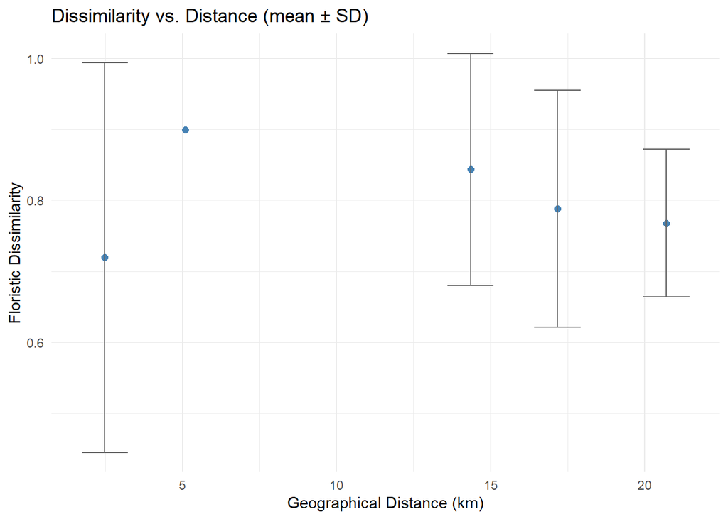

```r
geo_dist_forest <-
  dist(data_utm %>% select(X, Y, plot_name) %>%
         filter(plot_name %in% colnames(sp_plot_mat_forest)) %>%
                   column_to_rownames('plot_name'))

#### dissimilarité floristique
  ## Morisita - peu sensibles aux espèces 'rares'
mori_dist_f <-
  vegdist(t(sp_plot_mat_forest), method = "morisita")

df <- tibble(geo = geo_dist_forest/1000,
             sim = mori_dist_f)

bin_width <- 5

summary_df <- df %>%
  mutate(distance_bin = cut(
    geo,
    breaks = seq(0, max(geo), by = bin_width),
    include.lowest = TRUE
  )) %>%
  group_by(distance_bin) %>%
  summarise(
    mean_distance = mean(geo),
    mean_dissimilarity = mean(sim),
    sd_dissimilarity = sd(sim),
    n = n(),
    .groups = "drop"
  )

ggplot(summary_df, aes(x = mean_distance, y = mean_dissimilarity)) +
  geom_point(size = 2, color = "steelblue") +
  geom_errorbar(aes(ymin = mean_dissimilarity - sd_dissimilarity,
                    ymax = mean_dissimilarity + sd_dissimilarity),
                width = bin_width * 0.3,
                color = "gray40") +
  labs(x = "Geographical Distance (km)", y = "Floristic Dissimilarity",
       title = "Dissimilarity vs. Distance (mean ± SD)") +
  theme_minimal()
```

### Turnover floristique /distance pour les plots de savannes

```r
geo_dist_savana <-
  dist(data_utm %>% select(X, Y, plot_name) %>%
         filter(plot_name %in% colnames(sp_plot_mat_savana)) %>%
                   column_to_rownames('plot_name'))

mori_dist_s <-
  vegdist(t(sp_plot_mat_savana), method = "morisita")
df <- tibble(geo = geo_dist_savana/1000,
             sim = mori_dist_s)

bin_width <- 5

summary_df <- df %>%
  mutate(distance_bin = cut(geo, breaks = seq(0, max(geo), by = bin_width),
                            include.lowest = TRUE)) %>%
  group_by(distance_bin) %>%
  summarise(
    mean_distance = mean(geo),
    mean_dissimilarity = mean(sim, na.rm = T),
    sd_dissimilarity = sd(sim, na.rm = T),
    n = n(),
    .groups = "drop"
  )
```

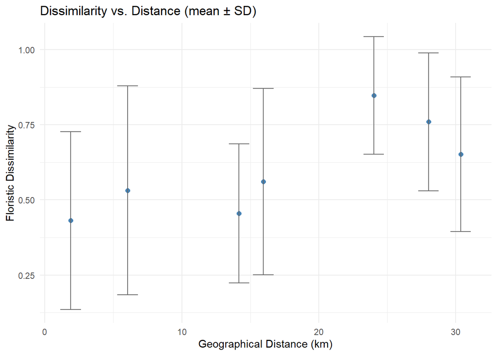

```r
ggplot(summary_df, aes(x = mean_distance, y = mean_dissimilarity)) +
  geom_point(size = 2, color = "steelblue") +
  geom_errorbar(aes(ymin = mean_dissimilarity - sd_dissimilarity,
                    ymax = mean_dissimilarity + sd_dissimilarity),
                width = bin_width * 0.3,
                color = "gray40") +
  labs(x = "Geographical Distance (km)", y = "Floristic Dissimilarity",
       title = "Dissimilarity vs. Distance (mean ± SD)") +
  theme_minimal()
```

### Turnover phylogénétique /distance pour les plots de forêts

```r
geo_dist_forest <-
  dist(data_utm %>% select(X, Y, plot_name) %>%
         filter(plot_name %in% colnames(sp_plot_mat_forest)) %>%
                   column_to_rownames('plot_name'))

pairwise_mpd <-
  picante::comdist(comm = t(sp_plot_mat_forest),
                   dis = cophenetic(phylo_tree_used),
                   abundance.weighted = TRUE)

df <- tibble(geo = geo_dist_forest/1000,
             sim = pairwise_mpd)

bin_width <- 5

summary_df <- df %>%
  mutate(distance_bin = cut(
    geo,
    breaks = seq(0, max(geo), by = bin_width),
    include.lowest = TRUE
  )) %>%
  group_by(distance_bin) %>%
  summarise(
    mean_distance = mean(geo),
    mean_dissimilarity = mean(sim),
    sd_dissimilarity = sd(sim),
    n = n(),
    .groups = "drop"
  )
```

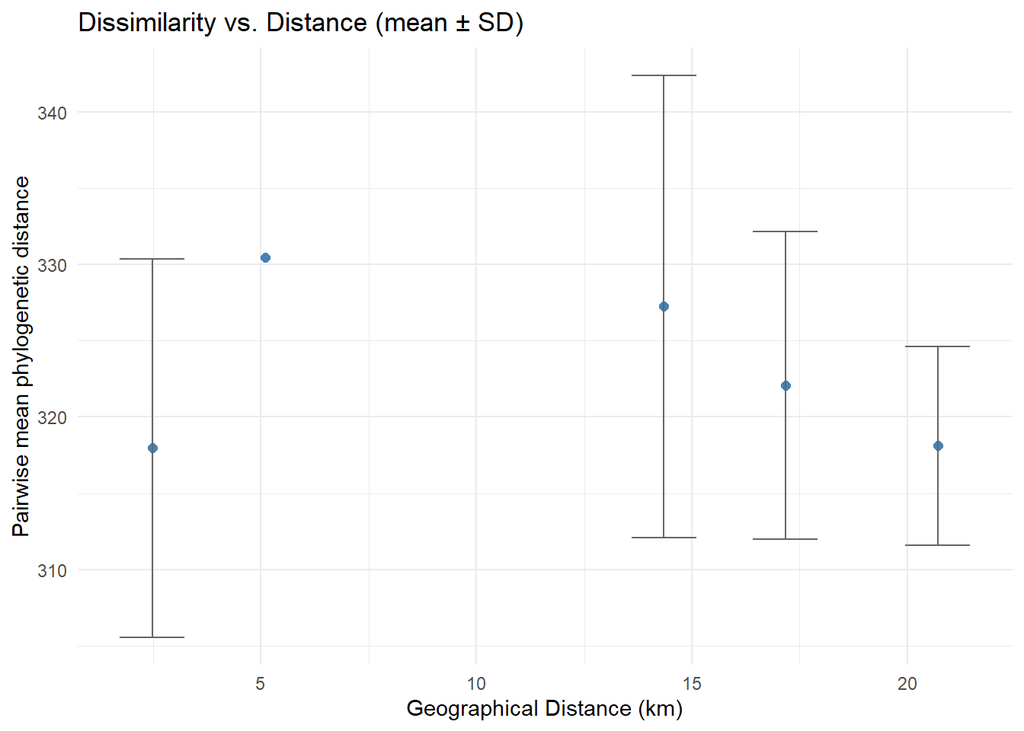

```r
ggplot(summary_df, aes(x = mean_distance, y = mean_dissimilarity)) +
  geom_point(size = 2, color = "steelblue") +
  geom_errorbar(aes(ymin = mean_dissimilarity - sd_dissimilarity,
                    ymax = mean_dissimilarity + sd_dissimilarity),
                width = bin_width * 0.3,
                color = "gray40") +
  labs(x = "Geographical Distance (km)",
       y = "Pairwise mean phylogenetic distance",
       title = "Dissimilarity vs. Distance (mean ± SD)") +
  theme_minimal()
```

### Turnover phylogénétique /distance pour les plots de savannes

```r
pairwise_mpd <-
  picante::comdist(comm = t(sp_plot_mat_savana),
                   dis = cophenetic(phylo_tree_used),
                   abundance.weighted = TRUE)

df <- tibble(geo = geo_dist_savana/1000,
             sim = pairwise_mpd)

bin_width <- 5

summary_df <- df %>%
  mutate(distance_bin = cut(
    geo,
    breaks = seq(0, max(geo), by = bin_width),
    include.lowest = TRUE
  )) %>%
  group_by(distance_bin) %>%
  summarise(
    mean_distance = mean(geo),
    mean_dissimilarity = mean(sim),
    sd_dissimilarity = sd(sim),
    n = n(),
    .groups = "drop"
  )
```

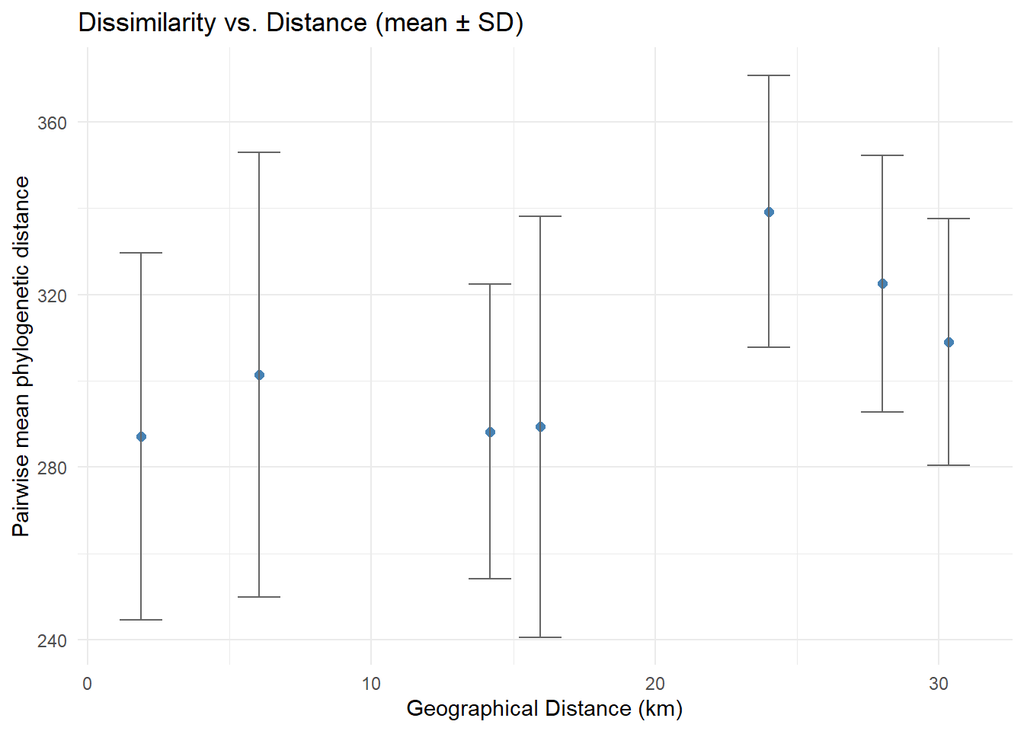

```r
ggplot(summary_df, aes(x = mean_distance, y = mean_dissimilarity)) +
  geom_point(size = 2, color = "steelblue") +
  geom_errorbar(aes(ymin = mean_dissimilarity - sd_dissimilarity,
                    ymax = mean_dissimilarity + sd_dissimilarity),
                width = bin_width * 0.3,
                color = "gray40") +
  labs(x = "Geographical Distance (km)",
       y = "Pairwise mean phylogenetic distance",
       title = "Dissimilarity vs. Distance (mean ± SD)") +
  theme_minimal()
```